# Figure 3a and 4b: CBP enhancers known motif enrichment analysis

**Project:** Enhancer identification

**Author:** Jeff Johnston

**Generated:** Sun Aug 21 2016, 12:57 PM

## Region counts

| diff_bound_class | count |
| --- | --- |
| Higher in gd7 | 380 |
| Higher in Toll10b | 416 |
| No change | 6352 |

## Assign FlyBase gene IDs to known motifs

## Calculate enrichments

We can now test for enrichment of known motifs using the results from DESeq. We will use an adjusted p-value cutoff of 0.05. Each Nejire peak has been resized to 201 bp centered on the Nejire ChIP-seq summit.

We do not test the following motifs:

- All JASPAR_CORE motifs, as they are duplicates of JASPAR_2014
- All daughterless (da) hetereodimer motifs
- All motifs where the corresponding transcription factor is not expressed in any of the three tissues (FPKM > 5)

This results in 346 tested motifs.

After removal, we calculate an adjusted p-value for each motif enrichment test.

## Calculate overlap values for pairs of significant motifs

We next calculate the overlap between all pairs of 38 significant motifs.

## Enrichment and overlap heat maps

Motif overlap table

| keep_motif | other_names |
| --- | --- |
| FlyFactorSurvey-AbdB_SOLEXA_FBgn0000015 | FlyFactorSurvey-AbdB_SOLEXA_FBgn0000015 |
| FlyFactorSurvey-brk_FlyReg_FBgn0024250 | JASPAR_2014-brk-MA0213.1 JASPAR_2014-Mad-MA0535.1 |
| FlyFactorSurvey-CG16778_SANGER_5_FBgn0003715 | FlyFactorSurvey-twi_FlyReg_FBgn0003900 JASPAR_2014-twi-MA0249.1 |
| FlyFactorSurvey-dl_NBT_FBgn0000462 | FlyFactorSurvey-lola.PC_SANGER_5_FBgn0005630 FlyFactorSurvey-Rel_SANGER_5_FBgn0014018 FlyFactorSurvey-shn.F1.2_SANGER_5_FBgn0003396 JASPAR_2014-dl_1-MA0022.1 JASPAR_2014-dl_2-MA0023.1 FlyFactorSurvey-… |
| FlyFactorSurvey-HLH106_SANGER_5_3_FBgn0261283 | FlyFactorSurvey-HLH106_SANGER_5_3_FBgn0261283 |
| FlyFactorSurvey-kni_SANGER_5_FBgn0001320 | FlyFactorSurvey-kni_SANGER_5_FBgn0001320 |
| FlyFactorSurvey-rib_SANGER_5_FBgn0003254 | FlyFactorSurvey-rib_SANGER_5_FBgn0003254 |
| FlyFactorSurvey-sna_SOLEXA_5_FBgn0003448 | FlyFactorSurvey-esg_SANGER_2.5_FBgn0001981 FlyFactorSurvey-sna_SANGER_10_FBgn0003448 |
| FlyFactorSurvey-Tin_SOLEXA_FBgn0004110 | FlyFactorSurvey-Vnd_Cell_FBgn0003986 FlyFactorSurvey-Vnd_SOLEXA_FBgn0003986 JASPAR_2014-vnd-MA0253.1 FlyFactorSurvey-Tin_Cell_FBgn0004110 |
| FlyFactorSurvey-vfl_SANGER_5_FBgn0259789 | FlyFactorSurvey-vfl_SOLEXA_5_FBgn0259789 FlyFactorSurvey-CG17181_SANGER_5_FBgn0035144 FlyFactorSurvey-CG17181_SOLEXA_5_FBgn0035144 FlyFactorSurvey-sna_FlyReg_FBgn0003448 |
| JASPAR_2014-BEAF-32-MA0529.1 | JASPAR_2014-BEAF-32-MA0529.1 |
| JASPAR_2014-Dll-MA0187.1 | FlyFactorSurvey-Abd.A_FlyReg_FBgn0000014 FlyFactorSurvey-ftz_FlyReg_FBgn0001077 |
| JASPAR_2014-eve-MA0221.1 | JASPAR_2014-zen-MA0256.1 FlyFactorSurvey-Dfd_SOLEXA_FBgn0000439 FlyFactorSurvey-Zen_SOLEXA_FBgn0004053 |

Motif pairs with more than 10% overlapping instances are combined, selecting the motif with the best p-value.

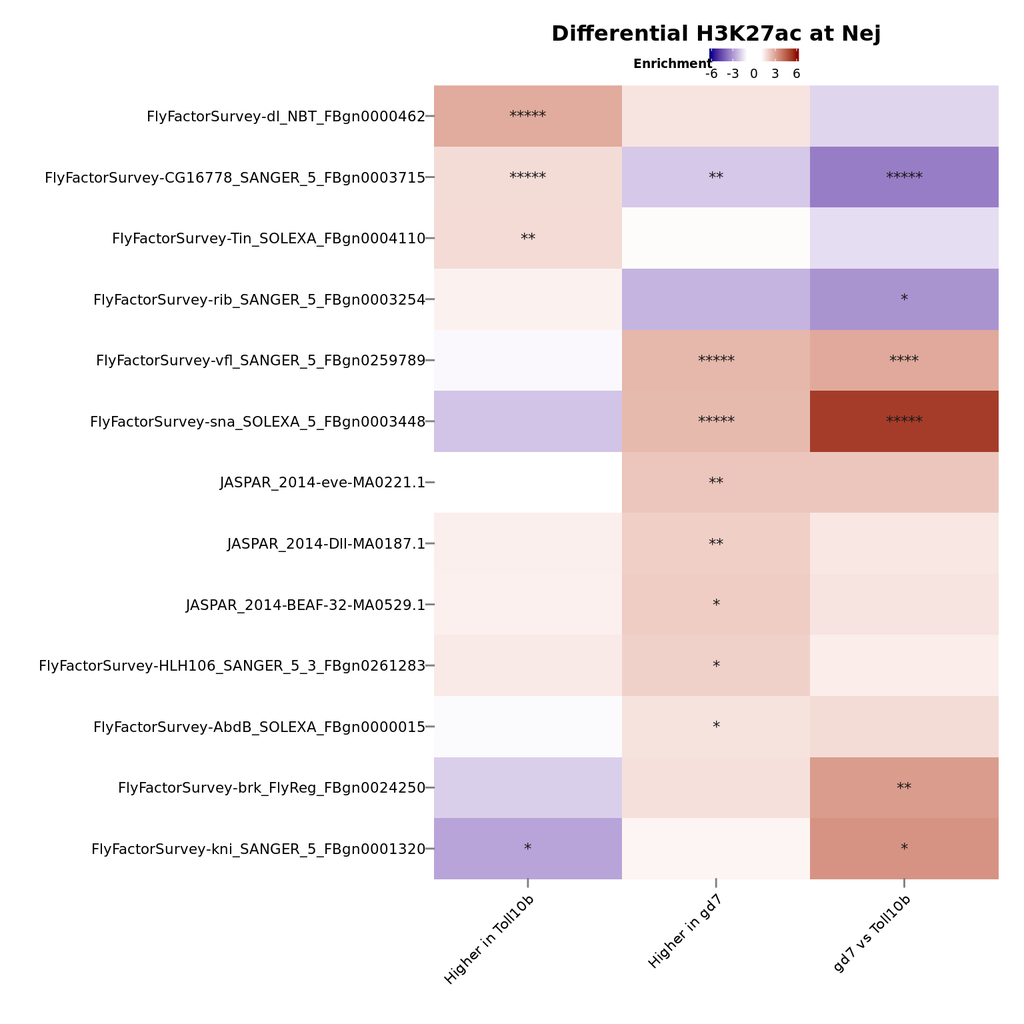

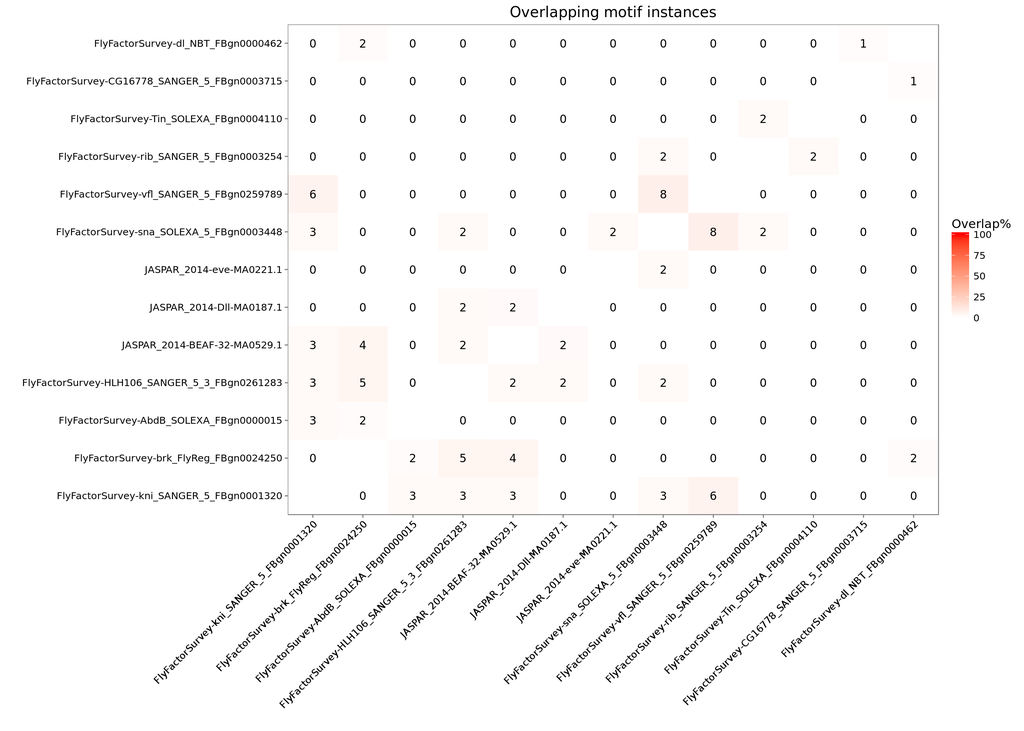

## Motif conservation

An alternative conservation plot:

- Background control: random non-TSS regions (201 bp)
- Average phastCon score of enhancers with each motif
- Average phastCon score of each motif

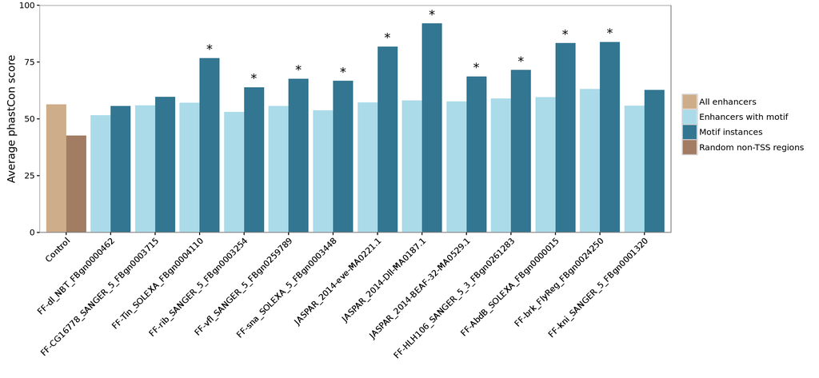

Significance testing for “Enhancers with motif” and “Motif instances”:

- Wilcox paired rank-sum test for the average conservation of all motif instances in each enhancer compared to the average conservation of the enhancer itself

All enhancers versus random non-TSS regions (unpaired)

| motif | bargroup | phastcon_score | n | pvalue_all_vs_random |
| --- | --- | --- | --- | --- |
| Control | Random non-TSS regions | 0.4268 | 5000 | 2.549e-44 |
| Control | All enhancers | 0.5643 | 796 | 2.549e-44 |

Motif instances versus enhancers with motif (paired)

| motif | enhancer_count | mean_motif | mean_enhancer | pvalue |
| --- | --- | --- | --- | --- |
| FF-AbdB_SOLEXA_FBgn0000015 | 67 | 0.8251779 | 0.5951602 | 4.484964e-07 |
| FF-brk_FlyReg_FBgn0024250 | 46 | 0.8336008 | 0.6312391 | 5.448284e-06 |
| FF-CG16778_SANGER_5_FBgn0003715 | 121 | 0.6019877 | 0.5599190 | 7.230396e-02 |
| FF-dl_NBT_FBgn0000462 | 65 | 0.5414650 | 0.5156892 | 1.996123e-01 |
| FF-HLH106_SANGER_5_3_FBgn0261283 | 36 | 0.7173472 | 0.5902435 | 6.042731e-03 |
| FF-kni_SANGER_5_FBgn0001320 | 32 | 0.6308008 | 0.5583685 | 8.287843e-02 |
| FF-rib_SANGER_5_FBgn0003254 | 39 | 0.6395299 | 0.5304086 | 2.628325e-02 |
| FF-sna_SOLEXA_5_FBgn0003448 | 57 | 0.6726709 | 0.5383696 | 4.483219e-04 |
| FF-Tin_SOLEXA_FBgn0004110 | 75 | 0.7643337 | 0.5708593 | 4.316180e-06 |
| FF-vfl_SANGER_5_FBgn0259789 | 93 | 0.6865860 | 0.5567836 | 7.666468e-05 |
| JASPAR_2014-BEAF-32-MA0529.1 | 39 | 0.6794069 | 0.5765579 | 3.580812e-03 |
| JASPAR_2014-Dll-MA0187.1 | 57 | 0.9180050 | 0.5811163 | 9.325484e-11 |
| JASPAR_2014-eve-MA0221.1 | 33 | 0.8174372 | 0.5723775 | 1.451228e-04 |

## Motif co-occurrence

Significant motif co-occurrence among all non-TSS Nejire peaks

|  | test_type | pvalue | overlap | totalA | totalB | universe | enrichment | motif1 | motif2 | adj_pv |
| --- | --- | --- | --- | --- | --- | --- | --- | --- | --- | --- |
| **1** | Depletion | 0.0003404 | 220 | 1276 | 1481 | 7148 | 0.8321 | FlyFactorSurvey-vfl_SANGER_5_FBgn0259789 | FlyFactorSurvey-CG16778_SANGER_5_FBgn0003715 | 0.008849 |
| **3** | Enrichment | 1.035e-196 | 419 | 1276 | 597 | 7148 | 3.932 | FlyFactorSurvey-vfl_SANGER_5_FBgn0259789 | FlyFactorSurvey-sna_SOLEXA_5_FBgn0003448 | 8.071e-195 |
| **27** | Depletion | 0.0005945 | 190 | 1917 | 855 | 7148 | 0.8286 | FlyFactorSurvey-dl_NBT_FBgn0000462 | FlyFactorSurvey-brk_FlyReg_FBgn0024250 | 0.01159 |
| **45** | Enrichment | 8.697e-09 | 79 | 734 | 407 | 7148 | 1.89 | JASPAR_2014-Dll-MA0187.1 | JASPAR_2014-eve-MA0221.1 | 3.392e-07 |

## Individual motifs

A PDF of motif logos for all significant motifs has been generated in the output folder for this document.